# Simple, static maps with ggplot2

M. Schrandt

6/8/2021

## Introduction

Often we want to plot geospatial data for something simple, like a map that shows occurrence of species counts in our sampling area, static maps for publications, etc.

Today, we’ll briefly cover how to get started with simple maps in ggplot. There are many ways to approach this, but I’ll try to get you started. We’ll make use of the r packages `tidyverse` (which contains `ggplot2`), `sf`, and `ggspatial`.

```r
## Load Libraries
library(tidyverse)
library(sf)
library(ggspatial) # north arrow and scale bar for map
```

## Today’s Data

### Point Data (fish counts)

We’ll be using a dataset of fish count data for 7 species of reef fish. The data are from a fisheries-independent monitoring survey of polyhaline seagrass beds along the West Florida Shelf, from 2008 to 2018. These data are available on Mendeley Data, as a .csv file (with accompanying metadata as a separate file): http://dx.doi.org/10.17632/9bzshm5h46.1

They are associated with a publication from FWC:  
Schrandt, M.N., Shea, C., Kurth, B., Switzer, T. 2021. Amending survey design to improve statistical inferences: monitoring recruitment of juvenile reef fish in the eastern Gulf of Mexico. Fisheries Research 241: 106015. https://doi.org/10.1016/j.fishres.2021.106015

Let’s read in our fish data:

```r
#  Reef fish species counts (including zeroes) from seagrass beds along West Florida Shelf
fishdat <- read.csv("Catch_Env_Data_new.csv", header = TRUE, stringsAsFactors = FALSE) %>%
  # reduce our columns; not all are needed
  select(Reference, Scientificname, N, Bay, Gear, Year, Month, Zone, Longitude, Latitude) %>%
  # reduce to only Tampa Bay (as opposed to all sampled estuaries)
  filter(Bay == "TB")

head(fishdat)
```

```
##       Reference        Scientificname N Bay Gear Year Month Zone Longitude
## 1 TBM2008060101 Centropristis striata 5  TB  160 2008     6    D -82.72248
## 2 TBM2008060101     Epinephelus morio 0  TB  160 2008     6    D -82.72248
## 3 TBM2008060101    Haemulon plumierii 0  TB  160 2008     6    D -82.72248
## 4 TBM2008060101  Lachnolaimus maximus 0  TB  160 2008     6    D -82.72248
## 5 TBM2008060101      Lutjanus griseus 0  TB  160 2008     6    D -82.72248
## 6 TBM2008060101     Lutjanus synagris 0  TB  160 2008     6    D -82.72248
##   Latitude
## 1 27.72268
## 2 27.72268
## 3 27.72268
## 4 27.72268
## 5 27.72268
## 6 27.72268
```

### Base Map

If we’re making a static map for a paper or publication, we’re also likely going to want/need a basemap shapefile.

The detailed state of Florida shoreline shapefile is large, so we’re going to subset the data to just Tampa Bay, and use a smaller shapefile to help with quicker rendering for this example.

Let’s read in the Tampa Bay shapefile:

```r
# Read in shapefile of TB geo
TBshore_sf_in <- sf::read_sf(dsn = ".", layer = "tb_geo") %>%
  #just keep the geometry column since that's all we need for this exercise (it contains lat/lon)
  select(geometry) %>%
  st_make_valid()

# check coordinate reference system
sf::st_crs(TBshore_sf_in)
```

```
## Coordinate Reference System:
##   User input: NAD83
##   wkt:
## GEOGCRS["NAD83",
##     DATUM["North American Datum 1983",
##         ELLIPSOID["GRS 1980",6378137,298.257222101,
##             LENGTHUNIT["metre",1]]],
##     PRIMEM["Greenwich",0,
##         ANGLEUNIT["degree",0.0174532925199433]],
##     CS[ellipsoidal,2],
##         AXIS["latitude",north,
##             ORDER[1],
##             ANGLEUNIT["degree",0.0174532925199433]],
##         AXIS["longitude",east,
##             ORDER[2],
##             ANGLEUNIT["degree",0.0174532925199433]],
##     ID["EPSG",4269]]
```

The coordinate reference system (CRS) is set to NAD83. Location data are collected using GPS, which typically uses the WGS84 (EPSG = 4326) CRS (you’ll want to check your unit to see how it records). I am going to transform/change the CRS of the base layer so that our points and base layer are in the same CRS.

```r
TBshore_sf <- st_transform(TBshore_sf_in, crs = 4326)
st_crs(TBshore_sf)
```

```
## Coordinate Reference System:
##   User input: EPSG:4326
##   wkt:
## GEOGCRS["WGS 84",
##     DATUM["World Geodetic System 1984",
##         ELLIPSOID["WGS 84",6378137,298.257223563,
##             LENGTHUNIT["metre",1]]],
##     PRIMEM["Greenwich",0,
##         ANGLEUNIT["degree",0.0174532925199433]],
##     CS[ellipsoidal,2],
##         AXIS["geodetic latitude (Lat)",north,
##             ORDER[1],
##             ANGLEUNIT["degree",0.0174532925199433]],
##         AXIS["geodetic longitude (Lon)",east,
##             ORDER[2],
##             ANGLEUNIT["degree",0.0174532925199433]],
##     USAGE[
##         SCOPE["Horizontal component of 3D system."],
##         AREA["World."],
##         BBOX[-90,-180,90,180]],
##     ID["EPSG",4326]]
```

## Plot our Base Map

If you’re familiar with plotting in ggplot, mapping really isn’t too different. We basically just use a different `geom`, and the aesthetics options, faceting, etc. are all still available.

Use the `geom_sf()` function to plot shapefiles. If you call `str(TBshore_sf)`, you’ll see it is a “POLYGON”…so if we want to color in the polygon, we use the `fill=` argument. If you want a different color for the outline, then use the `color` argument. You can change the thickness of the lines with the `size` argument. We have very detailed shorelines with this shapefile so I’m using a thin line.

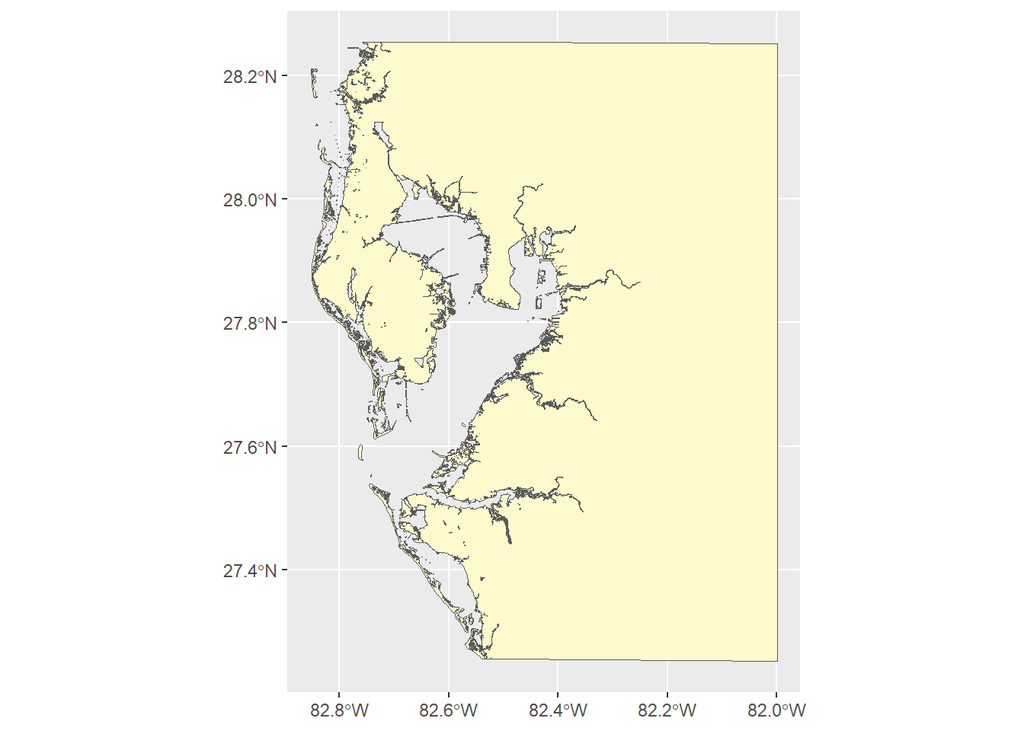

```r
base <- ggplot() +
  geom_sf(data = TBshore_sf, fill = "lemonchiffon", size = 0.1)
base
```

The `TBshore_sf` shapefile was cropped from the state of Florida shoreline shapefile (that’s why we get the straight lines on the north, south, and east sides. We can set the boundaries of our map with `coord_sf()` to basically crop out those lines.

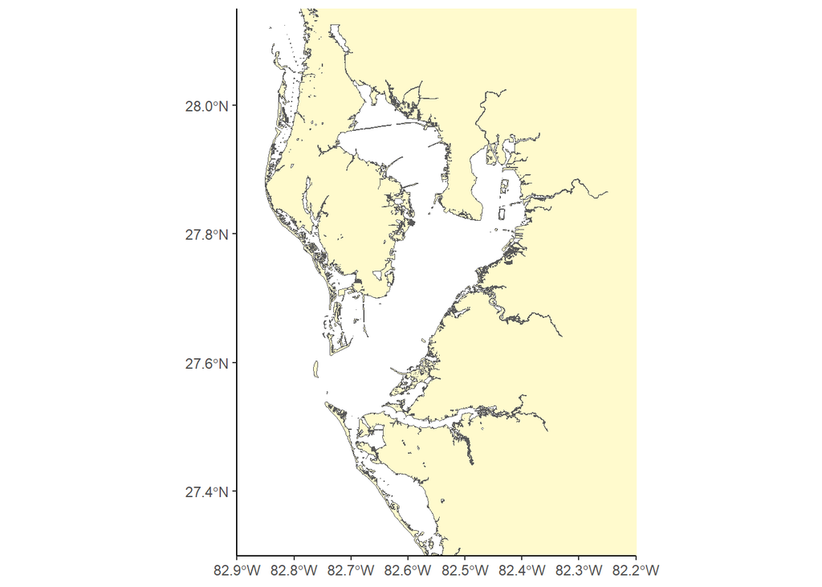

```r
base <- ggplot() +
  geom_sf(data = TBshore_sf, fill = "lemonchiffon", size = 0.1) +
  #set extent of coordinates
  coord_sf(xlim = c(-82.9, -82.2), ylim = c(27.3, 28.15), expand = FALSE) +
  theme_classic()
base
```

## Add Point Data

We can use `geom_point()` if our point data are not a shapefile, but we need to specify the lat/lon. You’ll need the column names of your latitude and longitude in your point data file. For `fishdat` they are called “Latitude” and “Longitude”

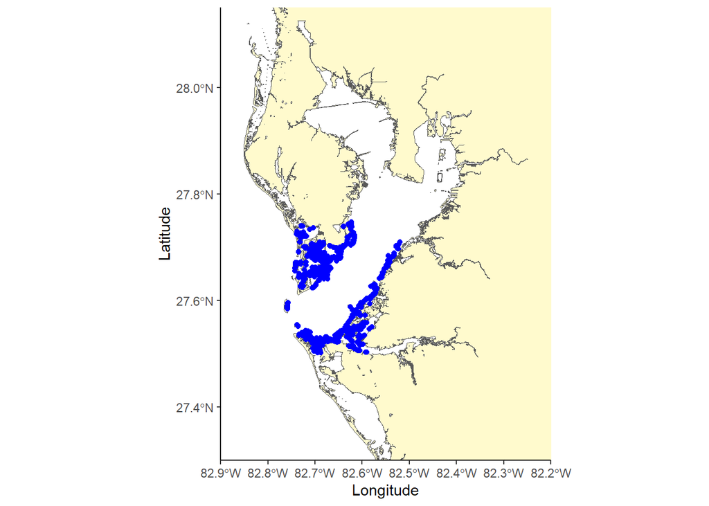

```r
base + geom_point(data = fishdat, aes(x = Longitude, y = Latitude), size = 1.5, color = "blue")
```

You’ll notice all the points fall in the southern portion of the estuary. This makes sense since the sampling survey is in polyhaline seagrass beds where the salinity is >= 18.

The better alternative is to turn your point data into an `sf` object using the `st_as_sf()` function. This will rely on `sf` to handle “on-the-fly” coordinate systems - this is very useful if your two objects (base map and point data) are not in the same projection.

```r
#crs 4326 is for WGS84, which is the crs of our base map shapefile
fishdat_sf <- st_as_sf(fishdat, coords = c("Longitude", "Latitude"), crs = 4326)
head(fishdat_sf)
```

```
## Simple feature collection with 6 features and 8 fields
## Geometry type: POINT
## Dimension:     XY
## Bounding box:  xmin: -82.72248 ymin: 27.72268 xmax: -82.72248 ymax: 27.72268
## Geodetic CRS:  WGS 84
##       Reference        Scientificname N Bay Gear Year Month Zone
## 1 TBM2008060101 Centropristis striata 5  TB  160 2008     6    D
## 2 TBM2008060101     Epinephelus morio 0  TB  160 2008     6    D
## 3 TBM2008060101    Haemulon plumierii 0  TB  160 2008     6    D
## 4 TBM2008060101  Lachnolaimus maximus 0  TB  160 2008     6    D
## 5 TBM2008060101      Lutjanus griseus 0  TB  160 2008     6    D
## 6 TBM2008060101     Lutjanus synagris 0  TB  160 2008     6    D
##                     geometry
## 1 POINT (-82.72248 27.72268)
## 2 POINT (-82.72248 27.72268)
## 3 POINT (-82.72248 27.72268)
## 4 POINT (-82.72248 27.72268)
## 5 POINT (-82.72248 27.72268)
## 6 POINT (-82.72248 27.72268)
```

*Note: Your `fishdat_sf` dataset has 1 less column than the original because the latitude and longitude have been combined into a single column called `geometry`.*

Also of note is the “bounding box” in the output. This is helpful if you want to set the limits of your map to the bounding box of this layer.

Now we can use `geom_sf()` to map our point data `sf` object, instead of `geom_point()`. Here I will change the point color to orange so we know it’s a different map.

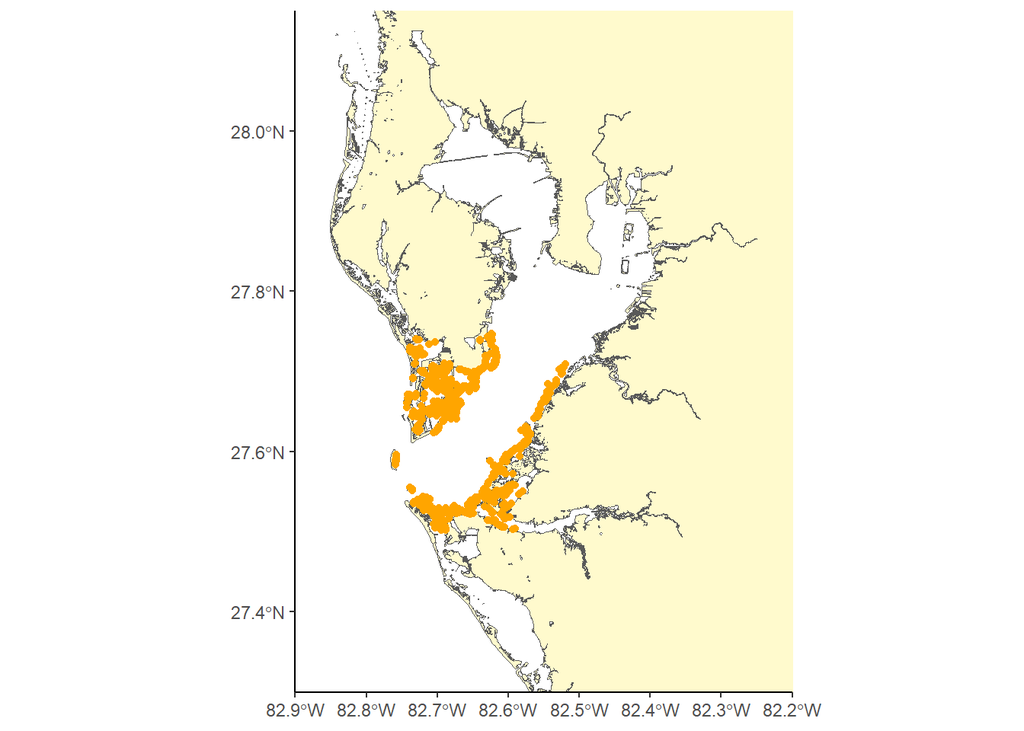

```r
p1 <- ggplot() +
  geom_sf(data = TBshore_sf, fill = "lemonchiffon", size = 0.1) +
  geom_sf(data = fishdat_sf, size = 1.5, color = "orange") +
  # you will need to re-do the limits
  coord_sf(xlim = c(-82.9, -82.2), ylim = c(27.3, 28.15), expand = FALSE) +
  theme_classic()
p1
```

## Bounding Box

Remember the bounding box I mentioned above? If we want to “zoom in” or limit the map to just the area of the points, we can use the bounding box information instead of the previous limits we provided.

```r
#extract the bounding box info from the shapefile
bbox <- sf::st_bbox(fishdat_sf)

bbox
```

```
##      xmin      ymin      xmax      ymax
## -82.75883  27.50183 -82.51988  27.74732
```

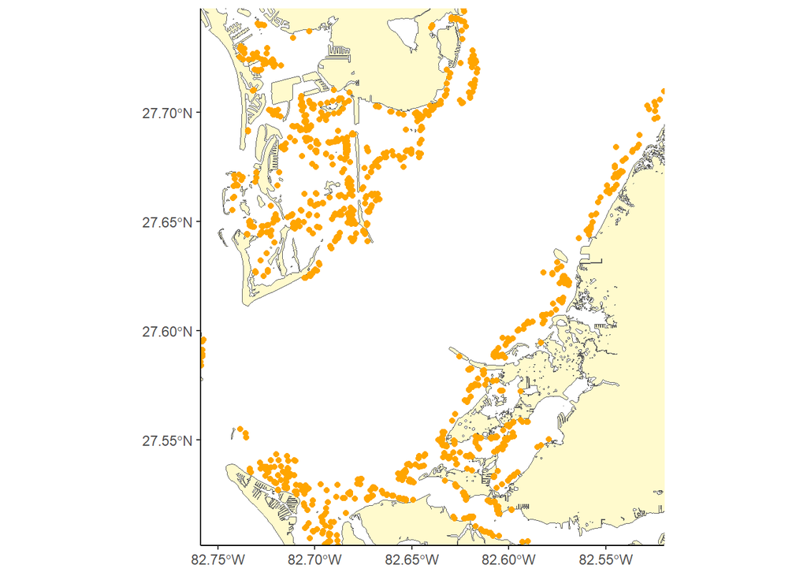

```r
p1_zoom <- ggplot() +
  geom_sf(data = TBshore_sf, fill = "lemonchiffon", size = 0.1) +
  geom_sf(data = fishdat_sf, size = 1.5, color = "orange") +
  # supply bounding box corrds as x and y limits
  coord_sf(xlim = c(bbox[1], bbox[3]), ylim = c(bbox[2], bbox[4]), expand = FALSE) +
  theme_classic()
p1_zoom
```

Be careful with this - your points end up right on the axes if you specify `expand = FALSE` as I did above. Change it to `TRUE` to add a little padding to the limits to ensure that the data and axes don’t overlap.

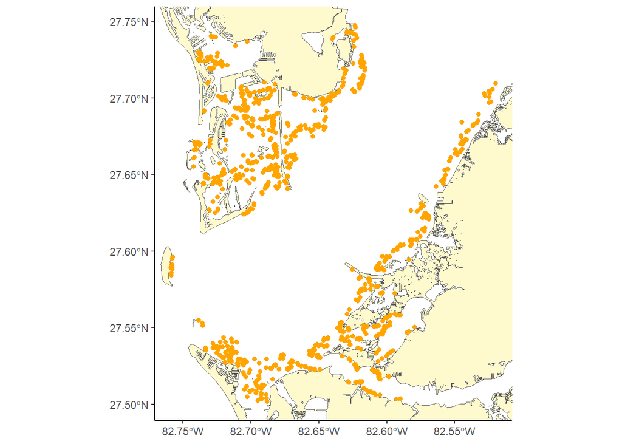

```r
p1_zoom2 <- ggplot() +
  geom_sf(data = TBshore_sf, fill = "lemonchiffon", size = 0.1) +
  geom_sf(data = fishdat_sf, size = 1.5, color = "orange") +
  # supply bounding box corrds as x and y limits
  coord_sf(xlim = c(bbox[1], bbox[3]), ylim = c(bbox[2], bbox[4]), expand = TRUE) +
  theme_classic()
p1_zoom2
```

## Add features with the `ggspatial` package

We can grab a north arrow and scale from the `ggspatial` package

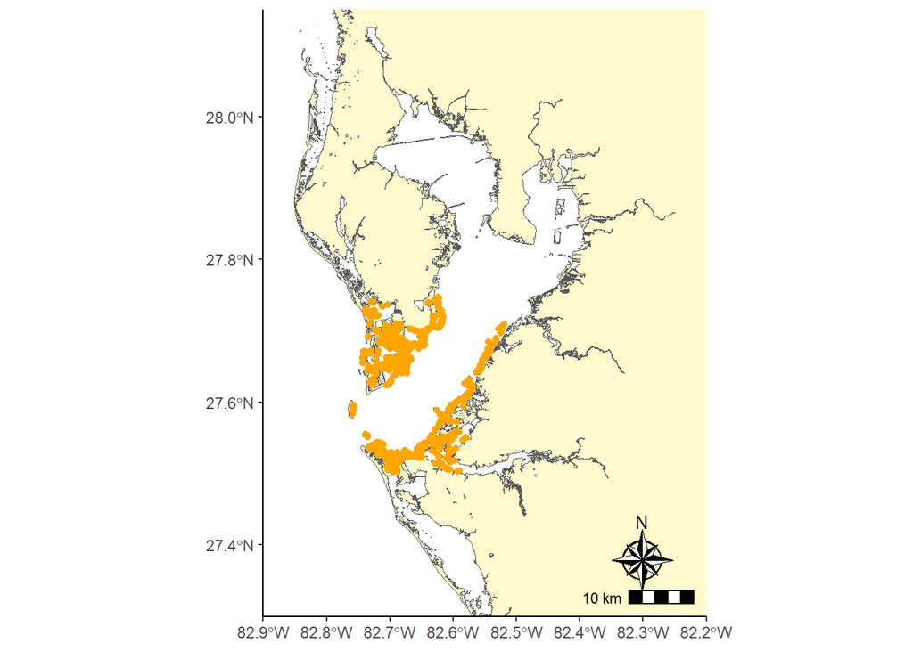

```r
p1 +
  #location "br" here refers to "bottom right"
  # north arrow styles: https://paleolimbot.github.io/ggspatial/reference/north_arrow_orienteering.html
  annotation_north_arrow(location = "br", which_north = "true", style = north_arrow_nautical(),
                         pad_x = unit(0.5, "cm"), pad_y = unit(0.5, "cm")) +
  annotation_scale(location = "br", width_hint = 0.25)
```

## You can save your map with `ggsave()`

## You can add annotations/text/legends if appropriate

## Examples of other ggplot features you can use…

Example: To color the points by gear type, use `aes()`:

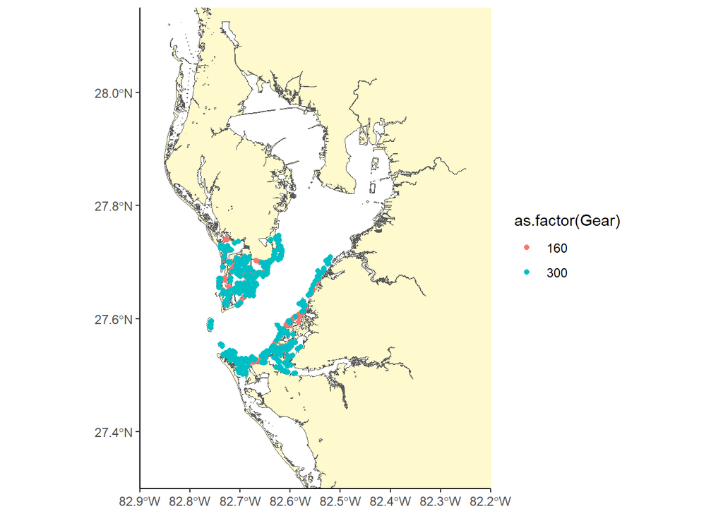

```r
p2 <- ggplot() +
  geom_sf(data = TBshore_sf, fill = "lemonchiffon", size = 0.1) +
  geom_sf(data = fishdat_sf, size = 1.5, aes(color = as.factor(Gear))) +
  # you will need to re-do the limits
  coord_sf(xlim = c(-82.9, -82.2), ylim = c(27.3, 28.15), expand = FALSE) +
  theme_classic()
p2
```

Example: To create a panel graphic, use `facet_grid()` or `facet_wrap()`

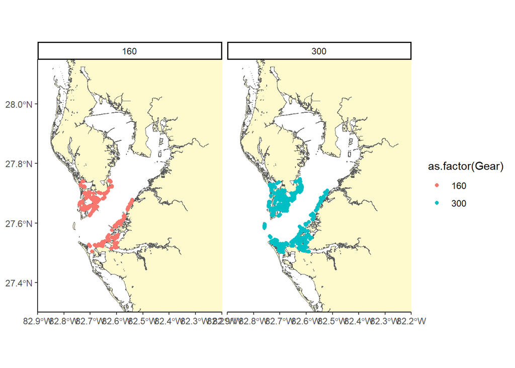

```r
p3 <- ggplot() +
  geom_sf(data = TBshore_sf, fill = "lemonchiffon", size = 0.1) +
  geom_sf(data = fishdat_sf, size = 1.5, aes(color = as.factor(Gear))) +
  facet_wrap(~Gear, ncol = 2) +
  # you will need to re-do the limits
  coord_sf(xlim = c(-82.9, -82.2), ylim = c(27.3, 28.15), expand = FALSE) +
  theme_classic()
p3
```

```r
# How to change ggplot facet labels:
# https://www.datanovia.com/en/blog/how-to-change-ggplot-facet-labels/
```

Example: Plot a single species occurrence over time in the trawl (Gear 300), for 2016-2018. This one could use some fine-tuning to make the x-axis legible.

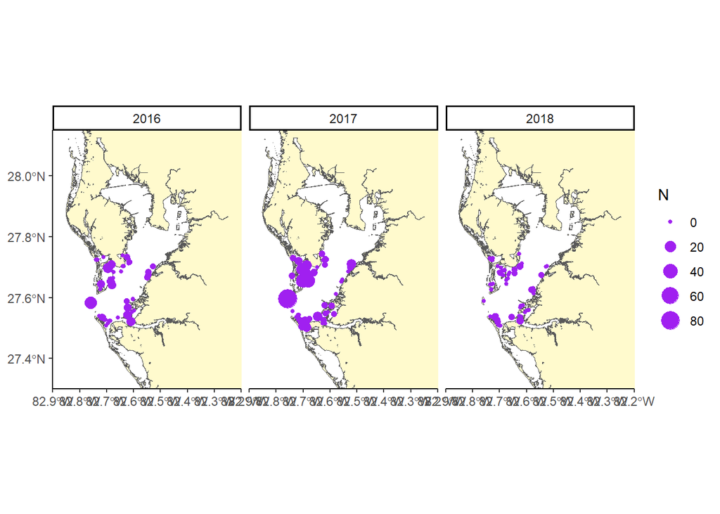

```r
Lsyn_dat <- fishdat_sf %>%
  filter(Scientificname == "Lutjanus synagris",
         Gear == 300,
         Year > 2015) %>%
  mutate(Year = as.integer(Year),
         Month = as.integer(Month))

p4 <- ggplot() +
  geom_sf(data = TBshore_sf, fill = "lemonchiffon", size = 0.1) +
  geom_sf(data = Lsyn_dat, aes(size = N), color = "purple") +
  facet_wrap(~Year) +
  # you will need to re-do the limits
  coord_sf(xlim = c(-82.9, -82.2), ylim = c(27.3, 28.15), expand = FALSE) +
  theme_classic()
p4
```

Example: Labeling boundaries/outlines. To reproduce the map (Figure 1) from Schrandt et al. 2021 (referenced at the beginning of this document), that these data are associated with, use the following code

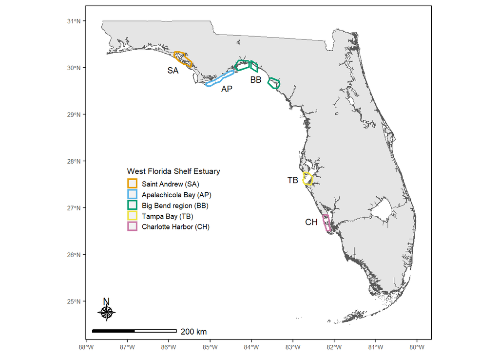

```r
#### Prep the base layer shape files ####
# Read in shapefile of Florida land
FLshoreline_sf <- read_sf(dsn = ".", layer = "Florida_land_40k_no_TB_bridges") %>%
  select(geometry) %>%
  st_make_valid()

# Read in the shapefile of WI sampling boundaries
WIbounds_sf <- read_sf(dsn = ".", layer = "WI_boundaries") %>%
  mutate(Bay = case_when(Id == 0 ~ "CH",
                         Id == 1 ~ "TB",
                         Id %in% c(2, 3, 4) ~ "BB",
                         Id == 5 ~ "AP",
                         Id == 6 ~ "SA")) %>%
  st_make_valid()

# name a look-up vector for area colors (this is where I specify what I want each Bay color to be)
BayCol <- c("CH" = "#CC79A7",
            "TB" = "#F0E442",
            "BB" = "#009E73",
            "AP" = "#56B4E9",
            "SA" = "#E69F00")

# make the static map
WIMap <- ggplot() +
  # first layer is the FL shoreline base layer
  geom_sf(data = FLshoreline_sf, fill = "gray90", size = 0.1) +
  # top layer is the WI sampling boundaries
  geom_sf(data = WIbounds_sf, aes(color = Bay), fill = NA, size = 0.8) +
  scale_color_manual(values = BayCol, breaks = c("SA", "AP", "BB", "TB", "CH"),
                     labels = c("Saint Andrew (SA)", "Apalachicola Bay (AP)", "Big Bend region (BB)",
                                "Tampa Bay (TB)", "Charlotte Harbor (CH)")) +
  scale_fill_manual(aes(fill = NA)) +
  annotation_north_arrow(location = "bl", which_north = "true", style = north_arrow_nautical(),
                         height = unit(0.8, "cm"), width = unit(0.8, "cm"),
                         pad_x = unit(0.35, "cm"), pad_y = unit(0.65, "cm")) +
  annotation_scale(location = "bl", width_hint = 0.25,
                   height = unit(0.1, "cm")) +
  #remove the background grid color, set legend position, etc.
  theme(panel.grid.major = element_blank(),
        panel.background = element_blank(),
        panel.border = element_rect(color = "black", fill = NA),
        legend.position = c(0.255, 0.42),
        legend.title = element_text(size = 8),
        legend.text = element_text(size = 7),
        legend.key.size = unit(0.75,"line"),
        axis.title.x = element_blank(),
        axis.title.y = element_blank(),
        axis.text.x = element_text(size = 6),
        axis.text.y = element_text(size = 6),
        #specify margins around the ggplot
        plot.margin=grid::unit(c(2,2,2,2), "mm")) +
  labs(y = "", x = "", color = "West Florida Shelf Estuary") +
  #add in bay-specific labels with annotate()
  annotate(geom = "text", x = -85.9, y = 29.95, label = "SA", size = 3) +
  annotate(geom = "text", x = -84.6, y = 29.55, label = "AP", size = 3) +
  annotate(geom = "text", x = -83.9, y = 29.75, label = "BB", size = 3) +
  annotate(geom = "text", x = -83, y = 27.6, label = "TB", size = 3) +
  annotate(geom = "text", x = -82.55, y = 26.7, label = "CH", size = 3)
WIMap
```

## Other Resources

ggplot2: Elegant graphics for data analysis, within the ggplot2 online book (https://ggplot2-book.org/index.html) https://ggplot2-book.org/maps.html

There are a lot of spatial references for R. Here is another one for sf and ggplot, specifically: https://www.jla-data.net/eng/merging-geometry-of-sf-objects-in-r/

Drawing beautiful maps programmatically: https://r-spatial.org/r/2018/10/25/ggplot2-sf.html

And the R Spatial Workshop_EPA: https://mhweber.github.io/AWRA_2020_R_Spatial/

## FWRI R Club Announcements

I’m still looking for volunteers to present something at a meeting of your choice; please consider sharing your skills with the group. Or, if you’re stuck on something and want feedback from the group, we can help!

Email if you’re interested in presenting or if you have a topic you’d like someone else to present.

Thanks!